# Análise dos dados faltantes

Agatha Rodrigues

20/03/2021

# Pacotes

```r
loadlibrary <- function(x) {
  if (!require(x, character.only = TRUE)) {
    install.packages(x, dependencies = T)
    if (!require(x, character.only = TRUE))
      stop("Package not found")
  }
}

packages <- c(
  "tidyverse",
  "readxl",
  "janitor",
  "skimr",
  "lubridate",
  "summarytools",
  "magrittr",
  "knitr",
  "esquisse",
  "viridis",
  "cowplot",
  "tidyr",
  "reshape2",
  "VIM",
  "mice",
  "VGAM",
  "nlme",
  "visreg",
  "lme4",
  "glmnet",
  "leaps",
  "glmmLasso",
  "glmmTMB",
  "mgcv",
  "writexl"
)
lapply(packages, loadlibrary)
```

Funções:

```r
getmode <- function(v) {
   which.max(tabulate(v))
}
```

# Dados

```r
dados <- read_excel("Base_TocoColoPerinatal.xls")
# View(dados)

dados <- clean_names(dados)
names(dados)
```

```
##  [1] "id"           "indic_aval"   "ig_aval"      "medida_colo"  "num_contra"
##  [6] "ovulos"       "corion"       "im"           "tescola"      "cor_branco"
## [11] "peso_pre"     "alt"          "imc"          "gesta"        "para"
## [16] "a"            "ind_ap"       "hv_tabagismo" "hv_alcool"    "hv_drogas"
## [21] "igp_parto"
```

```r
#Verifica a existência de valores que não deveriam existir nas
#variáveis ajustadas à essa função.

verifica_erro <- function(v){

  if(v %in% "ovulos"){
    any(as.data.frame(dados)$v != 1 & as.data.frame(dados)$v != 2)
  } else if(v %in% "corion"){
    any(as.data.frame(dados)$v != 1 & as.data.frame(dados)$v != 2)
  } else if(v != "ovulos"& v != "corion")
    any(as.data.frame(dados)$v != 0 & as.data.frame(dados)$v != 1)
}

list_var_names <- c("ovulos", "corion", "cor_branco", "ind_ap",
                    "hv_tabagismo", "hv_alcool", "hv_drogas")


sapply(list_var_names, verifica_erro)
```

```
##       ovulos       corion   cor_branco       ind_ap hv_tabagismo    hv_alcool
##        FALSE        FALSE        FALSE        FALSE        FALSE        FALSE
##    hv_drogas
##        FALSE
```

```r
dados$medida_colo[dados$medida_colo == 0] <- NA


dados$ovulos <- fct_recode(as.factor(dados$ovulos),
                           placebo = "1", progesterona = "2")
dados$corion <- fct_recode(as.factor(dados$corion),
                           "monocoriônica" = "1",
                           "dicoriônica" = "2")
dados[c("cor_branco",
        "ind_ap",
        "hv_tabagismo",
        "hv_alcool",
        "hv_drogas")] <-
  lapply(dados[c("cor_branco",
                 "ind_ap",
                 "hv_tabagismo",
                 "hv_alcool",
                 "hv_drogas")],
         factor,
         levels = c(0,1),
         labels = c("não","sim"))

dados$ig_aval_sem <- trunc(dados$ig_aval)
```

## Variáveis fixas

Vamos primeiro analisar as variáveis fixas.

```r
dados_fixas <- dados %>%
  filter(indic_aval == 1)  %>%
  select(-indic_aval,
         -ig_aval,
         -medida_colo,
         -num_contra,
         -imc,
         -ig_aval_sem,
         -imc)
```

Vi que há 2 dados faltantes em aborto (`a`), mas não há em gesta e nem em partos.

Uma coisa para mudar na base: `a` (aborto) é igual a gestações menos parto e menos 1.

```r
dados_fixas$a[is.na(dados_fixas$a)] <- dados_fixas$gesta[is.na(dados_fixas$a)] -  dados_fixas$para[is.na(dados_fixas$a)] - 1
```

Vamos criar uma variável auxiliar para ver o número de gestações ao considerar partos mais abortos e mais um (a gestação atual).

```r
aux <- dados_fixas$para + dados_fixas$a + 1
```

Mas note que para alguns casos (7 casos) o número de gestações (`gesta`) não é igual à variável auxiliar. Corrigimos isso no que segue:

```r
dados_fixas <- dados_fixas %>%
  mutate(gesta = para + a + 1)
```

Vamos agora ver as variáveis fixas que tem valores ausentes.

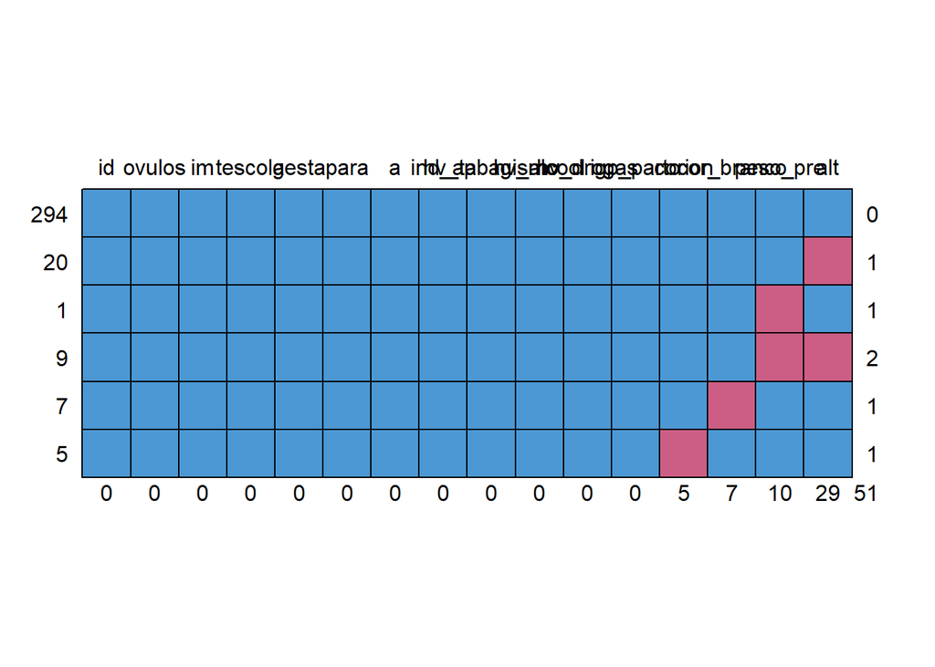

```
##     id ovulos im tescola gesta para a ind_ap hv_tabagismo hv_alcool hv_drogas
## 294  1      1  1       1     1    1 1      1            1         1         1
## 20   1      1  1       1     1    1 1      1            1         1         1
## 1    1      1  1       1     1    1 1      1            1         1         1
## 9    1      1  1       1     1    1 1      1            1         1         1
## 7    1      1  1       1     1    1 1      1            1         1         1
## 5    1      1  1       1     1    1 1      1            1         1         1
##      0      0  0       0     0    0 0      0            0         0         0
##     igp_parto corion cor_branco peso_pre alt
## 294         1      1          1        1   1  0
## 20          1      1          1        1   0  1
## 1           1      1          1        0   1  1
## 9           1      1          1        0   0  2
## 7           1      1          0        1   1  1
## 5           1      0          1        1   1  1
##             0      5          7       10  29 51
```

```r
md.pattern(dados_fixas)
```

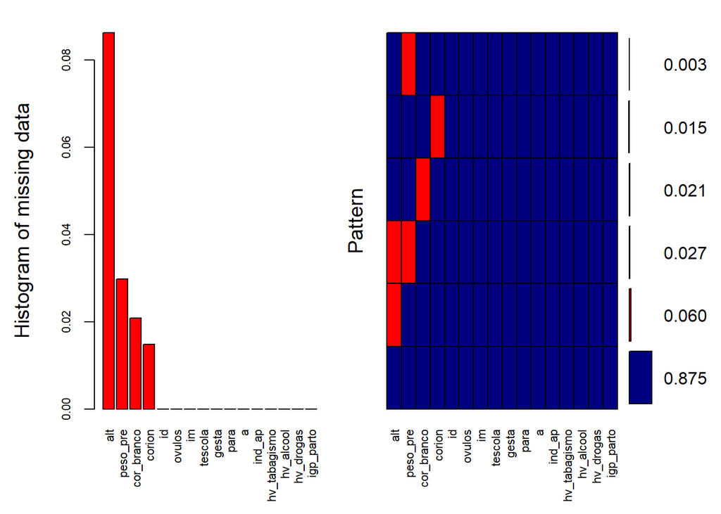

```
##
##  Variables sorted by number of missings:
##      Variable      Count
##           alt 0.08630952
##      peso_pre 0.02976190
##    cor_branco 0.02083333
##        corion 0.01488095
##            id 0.00000000
##        ovulos 0.00000000
##            im 0.00000000
##       tescola 0.00000000
##         gesta 0.00000000
##          para 0.00000000
##             a 0.00000000
##        ind_ap 0.00000000
##  hv_tabagismo 0.00000000
##     hv_alcool 0.00000000
##     hv_drogas 0.00000000
##     igp_parto 0.00000000
```

```r
aggr_plot <-
  aggr(
    dados_fixas,
    col = c('navyblue', 'red'),
    numbers = TRUE,
    sortVars = TRUE,
    labels = names(dados_fixas),
    cex.axis = .7,
    gap = 3,
    ylab = c("Histogram of missing data", "Pattern")
  )
```

Usamos o método MICE para imputar os dados faltantes para as variáveis fixas.

```r
mice_dados_fixas <-
  mice(
    dados_fixas,
    m = 10,
    maxit = 50,
    meth = 'pmm',
    seed = 500
  )
# summary(mice_dados_fixas)
```

```r
aux_dados_fixas <- complete(mice_dados_fixas, "all",  mild = TRUE)

sem <- c("corion", "cor_branco", "peso_pre",
         "alt")
nrep <- c("1", "2", "3", "4", "5", "6", "7", "8", "9", "10")

aux <- matrix(0, nrow = dim(dados_fixas)[1], ncol = length(sem))
for (i in 1:2) {
  out <- aux_dados_fixas[[nrep[1]]][[sem[i]]]
  for (j in 2:length(nrep)) {
    out <- cbind(out, aux_dados_fixas[[nrep[j]]][[sem[i]]])
  }
  for (k in 1:dim(dados_fixas)[1]) {
    aux[k, i] <- getmode(out[k, ])
  }
}
for (i in 3:4) {
  out <- matrix(0, ncol = 1, nrow = dim(dados_fixas)[1])
  for (j in 1:length(nrep)) {
    out <- aux_dados_fixas[[nrep[j]]][[sem[i]]] + out
  }
  aux[, i] <- out / length(nrep)
}

dados_fixas_completo <-
  data.frame(
    id = aux_dados_fixas[["1"]][["id"]],
    ovulos = aux_dados_fixas[["1"]][["ovulos"]],
    corion = aux[, 1],
    im = aux_dados_fixas[["1"]][["im"]],
    tescola = aux_dados_fixas[["1"]][["tescola"]],
    cor_branco = aux[, 2],
    peso_pre = aux[, 3],
    alt = aux[, 4],
    gesta = aux_dados_fixas[["1"]][["gesta"]],
    para = aux_dados_fixas[["1"]][["para"]],
    a = aux_dados_fixas[["1"]][["a"]],
    ind_ap = aux_dados_fixas[["1"]][["ind_ap"]],
    hv_tabagismo = aux_dados_fixas[["1"]][["hv_tabagismo"]],
    hv_alcool = aux_dados_fixas[["1"]][["hv_alcool"]],
    hv_drogas = aux_dados_fixas[["1"]][["hv_drogas"]],
    igp_parto = aux_dados_fixas[["1"]][["igp_parto"]]
  )

dados_fixas_completo$corion <-
  fct_recode(
    as.factor(dados_fixas_completo$corion),
    "monocoriônica" = "1",
    "dicoriônica" = "2"
  )

dados_fixas_completo$cor_branco <-
  fct_recode(as.factor(dados_fixas_completo$cor_branco),
             "não" = "1",
             "sim" = "2")

dados_fixas_completo <- dados_fixas_completo %>%
  mutate(imc = peso_pre / (alt ^ 2))
```

Agora vamos criar uma base concatenando as variáveis longitudinais e também as variáveis fixas, mas agora com a imputação.

```r
dados_long <- dados %>%
  select(id, indic_aval, ig_aval, ig_aval_sem, medida_colo, num_contra)
```

```r
dados_obs <- full_join(dados_long, dados_fixas_completo, by="id")
```

## Medida do colo

```r
dados1 <- dados_obs %>%
  select(id, ig_aval_sem, medida_colo) %>%
  spread(key = ig_aval_sem, value = medida_colo)
```

Vamos ver o padrão de dados ausentes para medida do colo

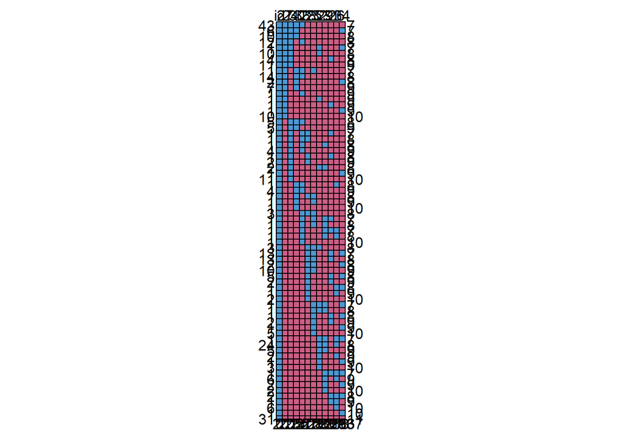

```
##    id  27  24  30  33  28  25  32  29  31  26  34
## 43  1   1   1   1   1   0   0   0   0   0   0   0    7
## 6   1   1   1   1   0   0   0   0   0   0   0   1    7
## 10  1   1   1   1   0   0   0   0   0   0   0   0    8
## 12  1   1   1   0   1   0   0   0   0   0   0   0    8
## 1   1   1   1   0   0   0   0   1   0   0   0   1    7
## 10  1   1   1   0   0   0   0   1   0   0   0   0    8
## 4   1   1   1   0   0   0   0   0   0   1   0   0    8
## 11  1   1   1   0   0   0   0   0   0   0   0   0    9
## 1   1   1   0   1   1   0   1   0   0   0   0   0    7
## 14  1   1   0   1   1   0   0   0   0   0   0   0    8
## 2   1   1   0   1   0   0   0   0   0   0   0   1    8
## 7   1   1   0   1   0   0   0   0   0   0   0   0    9
## 1   1   1   0   0   1   0   0   0   0   0   0   0    9
## 1   1   1   0   0   0   0   0   1   0   0   0   0    9
```

[output cut: 57 more lines]

```r
md.pattern(dados1)
```

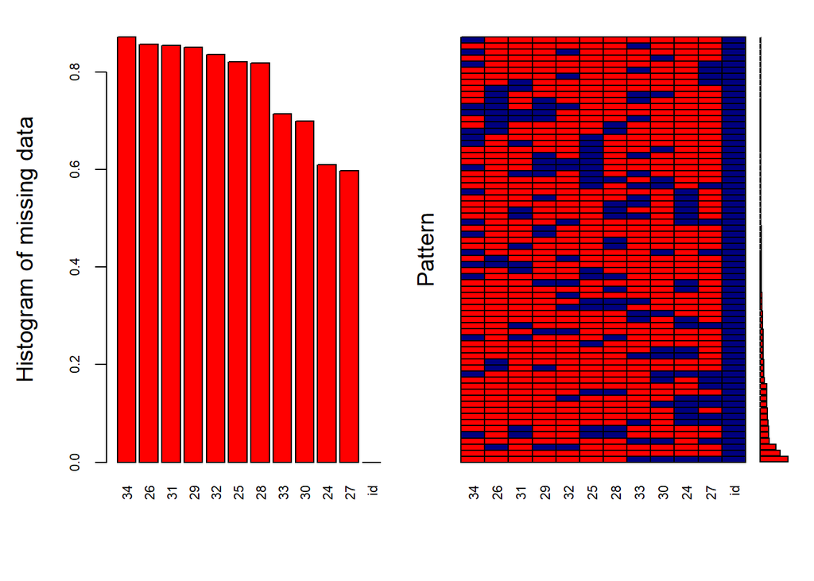

```
##
##  Variables sorted by number of missings:
##  Variable     Count
##        34 0.8720238
##        26 0.8571429
##        31 0.8541667
##        29 0.8511905
##        32 0.8363095
##        25 0.8214286
##        28 0.8184524
##        33 0.7142857
##        30 0.6994048
##        24 0.6101190
##        27 0.5982143
##        id 0.0000000
```

```r
aggr_plot <-
  aggr(
    dados1,
    col = c('navyblue', 'red'),
    numbers = TRUE,
    sortVars = TRUE,
    labels = names(dados1),
    cex.axis = .7,
    gap = 3,
    ylab = c("Histogram of missing data", "Pattern")
  )
```

```r
dados1$falt_medida <- apply(dados1[, 2:12], 1,
                            function(x)
                              sum(is.na(x)))
```

```r
table(dados1$falt_medida)
```

```
##
##   7   8   9  10  11
##  70 121  72  42  31
```

Vamos considerar apenas os casos com pelo menos 2 avaliações, ou seja, que a variável `falt_medida` seja menor ou igual a 9.

```r
dados2 <- dados1 %>%
  filter(falt_medida <= 9)
dim(dados2)
```

```
## [1] 263  13
```

Agora vamos realizar nova análise de dados faltantes.

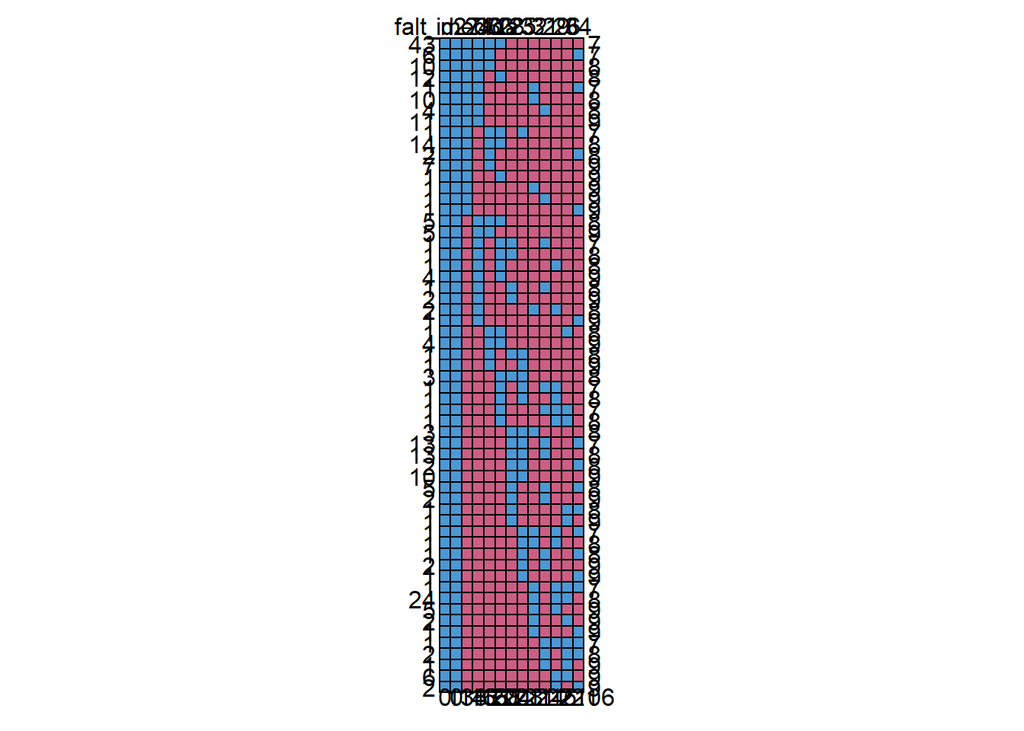

```
##    id falt_medida  27  24  30  33  28  25  32  31  29  26  34
## 43  1           1   1   1   1   1   0   0   0   0   0   0   0    7
## 6   1           1   1   1   1   0   0   0   0   0   0   0   1    7
## 10  1           1   1   1   1   0   0   0   0   0   0   0   0    8
## 12  1           1   1   1   0   1   0   0   0   0   0   0   0    8
## 1   1           1   1   1   0   0   0   0   1   0   0   0   1    7
## 10  1           1   1   1   0   0   0   0   1   0   0   0   0    8
## 4   1           1   1   1   0   0   0   0   0   1   0   0   0    8
## 11  1           1   1   1   0   0   0   0   0   0   0   0   0    9
## 1   1           1   1   0   1   1   0   1   0   0   0   0   0    7
## 14  1           1   1   0   1   1   0   0   0   0   0   0   0    8
## 2   1           1   1   0   1   0   0   0   0   0   0   0   1    8
## 7   1           1   1   0   1   0   0   0   0   0   0   0   0    9
## 1   1           1   1   0   0   1   0   0   0   0   0   0   0    9
## 1   1           1   1   0   0   0   0   0   1   0   0   0   0    9
```

[output cut: 46 more lines]

```r
md.pattern(dados2)
```

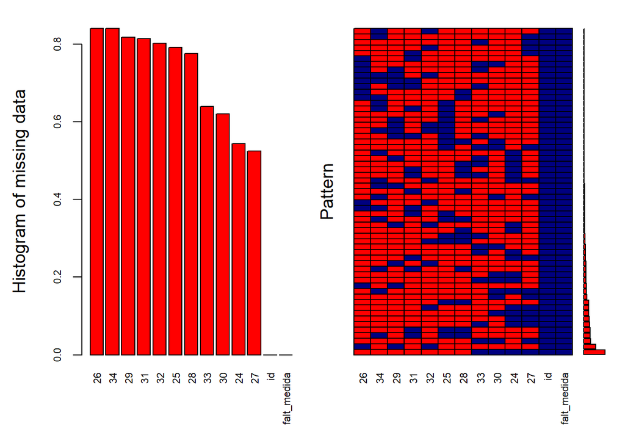

```
##
##  Variables sorted by number of missings:
##     Variable     Count
##           26 0.8403042
##           34 0.8403042
##           29 0.8174905
##           31 0.8136882
##           32 0.8022814
##           25 0.7908745
##           28 0.7756654
##           33 0.6387833
##           30 0.6197719
##           24 0.5437262
##           27 0.5247148
##           id 0.0000000
##  falt_medida 0.0000000
```

```r
aggr_plot <-
  aggr(
    dados2,
    col = c('navyblue', 'red'),
    numbers = TRUE,
    sortVars = TRUE,
    labels = names(dados2),
    cex.axis = .7,
    gap = 3,
    ylab = c("Histogram of missing data", "Pattern")
  )
```

Vamos retirar dos dados completos (com todas as variáveis) os casos não selecionados por medida do colo, ou seja, aqueles casos que não tem pelo menos duas observações.

```r
dados2_gather <- gather(data = dados2, key ="ig_aval_sem", value = "medida_colo", "24", "25", "26", "27", "28", "29", "30", "31", "32", "33", "34")

dados2_gather <- dados2_gather %>%
  mutate(ig_aval_sem = as.numeric(ig_aval_sem))

ids <- unique(dados2_gather$id)

#base só com as fixas soh com dados de pelo menos 2 avaliações do colo
dados_fixas_completo2 <- filter(dados_fixas_completo, id %in% ids)

dados_obs2 <- full_join(dados_fixas_completo2, dados2_gather, by= c("id"))

dados_obs2 <- dados_obs2 %>%
  arrange(id, ig_aval_sem)
```

Vamos ver a porcentagem de dados faltantes por idade gestacional:

```r
dados_obs2 %>%
  group_by(ig_aval_sem) %>%
  summarise(nmedida = sum(is.na(medida_colo))/n())
```

```
## # A tibble: 11 x 2
##    ig_aval_sem nmedida
##          <dbl>   <dbl>
##  1          24   0.544
##  2          25   0.791
##  3          26   0.840
##  4          27   0.525
##  5          28   0.776
##  6          29   0.817
##  7          30   0.620
##  8          31   0.814
##  9          32   0.802
## 10          33   0.639
## 11          34   0.840
```

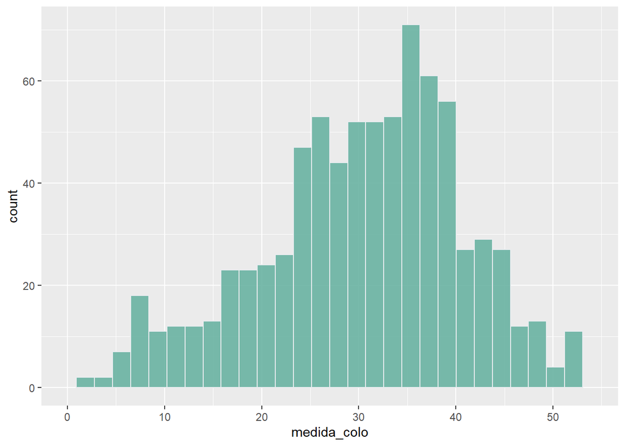

```r
ggplot(data = dados_obs2, aes(x = medida_colo)) +
  geom_histogram(fill = "#69b3a2",
                 color = "#e9ecef",
                 alpha = 0.9) +
  scale_x_continuous(limits = c(0, 54), breaks = seq(0, 54, 10)) +
  theme(plot.title = element_text(size = 15))
```

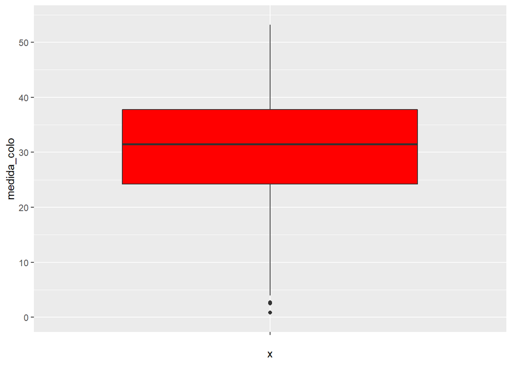

```r
ggplot(data = dados_obs2, aes(y = medida_colo, x = "")) +
  geom_boxplot(fill = "red") +
  scale_y_continuous(limits = c(0, 54), breaks = seq(0, 54, 10)) +
  theme(plot.title = element_text(size = 15))
```

**Modelo para medida do colo:**

```r
aj1 <- lme(medida_colo ~ ig_aval_sem + ovulos + corion + im + tescola + cor_branco + imc + gesta + ind_ap + hv_tabagismo + hv_alcool +  hv_drogas,
          random = ~ 1|id,
          data = dados_obs2, na.action = na.omit)   #summary(aj1)

aj2 <- lme(medida_colo ~ ig_aval_sem + ovulos + corion + im + tescola + cor_branco + imc + gesta + ind_ap + hv_alcool +  hv_drogas,
          random = ~ 1|id,
          data = dados_obs2, na.action = na.omit)  #summary(aj2)

aj3 <- lme(medida_colo ~ ig_aval_sem + ovulos + im + tescola + cor_branco + imc + gesta + ind_ap + hv_alcool +  hv_drogas,
          random = ~ 1|id,
          data = dados_obs2, na.action = na.omit)  #summary(aj3)

aj4 <- lme(medida_colo ~ ig_aval_sem + ovulos + im + tescola + cor_branco + imc + gesta + ind_ap + hv_alcool,
          random = ~ 1|id,
          data = dados_obs2, na.action = na.omit)   #summary(aj4)

aj5 <- lme(medida_colo ~ ig_aval_sem + ovulos + im + cor_branco + imc + gesta + ind_ap + hv_alcool,
          random = ~ 1|id,
          data = dados_obs2, na.action = na.omit)  #summary(aj5)

aj6 <- lme(medida_colo ~ ig_aval_sem + ovulos + im + cor_branco + imc + gesta + hv_alcool,
          random = ~ 1|id,
          data = dados_obs2, na.action = na.omit)  #summary(aj6)

aj7 <- lme(medida_colo ~ ig_aval_sem + ovulos + im + cor_branco + imc + hv_alcool,
          random = ~ 1|id,
          data = dados_obs2, na.action = na.omit)  #summary(aj7)

aj8 <- lme(medida_colo ~ ig_aval_sem + ovulos + im + cor_branco + imc,
          random = ~ 1|id,
          data = dados_obs2, na.action = na.omit)  #summary(aj8)

aj9 <- lme(medida_colo ~ ig_aval_sem + im + cor_branco + imc,
          random = ~ 1|id,
          data = dados_obs2, na.action = na.omit)  #summary(aj9)

xnam <- c("ig_aval_sem", "im", "cor_branco", "imc")
fmla <- as.formula(paste("medida_colo ~ ", paste(xnam, collapse= "+"), paste("+ (1|id)",collapse= "+")))

aj <- lmer(fmla, data = dados_obs2, na.action = na.omit)
pred <- predict(aj, newdata = dados_obs2, re.form=NA)

dados_obs2 <- dados_obs2 %>%
  mutate(medida_colo_compl = ifelse(
    is.na(medida_colo), pred, medida_colo)
    )
str(dados_obs2)
```

```
## 'data.frame':    2893 obs. of  21 variables:
##  $ id               : num  18210 18210 18210 18210 18210 ...
##  $ ovulos           : Factor w/ 2 levels "placebo","progesterona": 1 1 1 1 1 1 1 1 1 1 ...
##  $ corion           : Factor w/ 2 levels "monocoriônica",..: 2 2 2 2 2 2 2 2 2 2 ...
##  $ im               : num  29 29 29 29 29 29 29 29 29 29 ...
##  $ tescola          : num  11 11 11 11 11 11 11 11 11 11 ...
##  $ cor_branco       : Factor w/ 2 levels "não","sim": 2 2 2 2 2 2 2 2 2 2 ...
##  $ peso_pre         : num  93 93 93 93 93 93 93 93 93 93 ...
##  $ alt              : num  1.63 1.63 1.63 1.63 1.63 1.63 1.63 1.63 1.63 1.63 ...
##  $ gesta            : num  3 3 3 3 3 3 3 3 3 3 ...
##  $ para             : num  1 1 1 1 1 1 1 1 1 1 ...
##  $ a                : num  1 1 1 1 1 1 1 1 1 1 ...
##  $ ind_ap           : Factor w/ 2 levels "não","sim": 2 2 2 2 2 2 2 2 2 2 ...
##  $ hv_tabagismo     : Factor w/ 2 levels "não","sim": 1 1 1 1 1 1 1 1 1 1 ...
##  $ hv_alcool        : Factor w/ 2 levels "não","sim": 1 1 1 1 1 1 1 1 1 1 ...
##  $ hv_drogas        : Factor w/ 2 levels "não","sim": 1 1 1 1 1 1 1 1 1 1 ...
##  $ igp_parto        : num  37.6 37.6 37.6 37.6 37.6 37.6 37.6 37.6 37.6 37.6 ...
##  $ imc              : num  35 35 35 35 35 ...
##  $ falt_medida      : int  8 8 8 8 8 8 8 8 8 8 ...
##  $ ig_aval_sem      : num  24 25 26 27 28 29 30 31 32 33 ...
##  $ medida_colo      : num  45.2 NA NA 45 NA NA NA NA NA 33 ...
##  $ medida_colo_compl: num  45.2 39.7 38.5 45 36.2 ...
```

## Número de contrações

```r
remove(dados1)
remove(dados2)
remove(dados2_gather)
```

```r
dados1 <- dados_obs %>%
  select(id, ig_aval_sem, num_contra) %>%
  spread(key = ig_aval_sem, value = num_contra)
```

Vamos ver o padrão de dados ausentes para número de contrações.

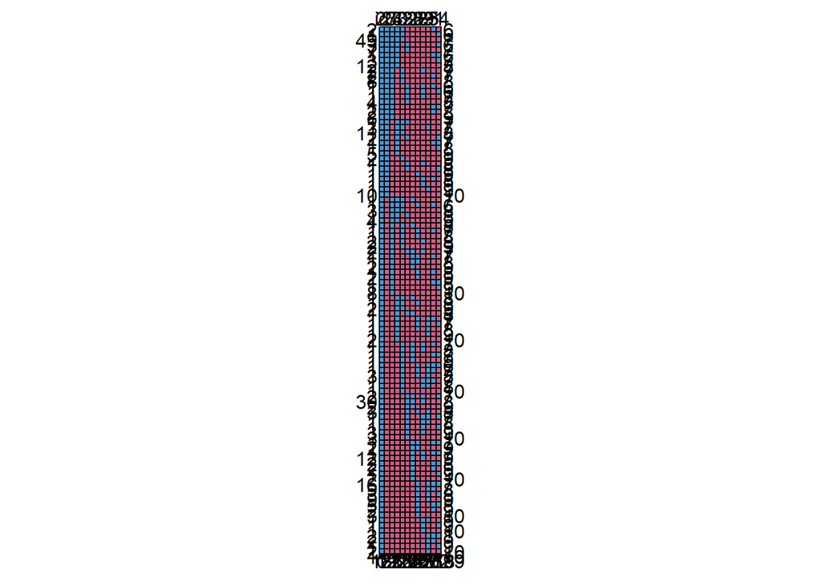

```
##    id  27  24  30  33  32  26  28  29  25  31  34
## 2   1   1   1   1   1   0   0   0   0   0   1   0    6
## 1   1   1   1   1   1   0   0   0   0   0   0   1    6
## 49  1   1   1   1   1   0   0   0   0   0   0   0    7
## 3   1   1   1   1   0   1   0   0   0   0   0   1    6
## 7   1   1   1   1   0   1   0   0   0   0   0   0    7
## 1   1   1   1   1   0   0   0   0   0   0   1   1    6
## 3   1   1   1   1   0   0   0   0   0   0   0   1    7
## 12  1   1   1   1   0   0   0   0   0   0   0   0    8
## 2   1   1   1   0   1   0   0   0   1   0   0   0    7
## 2   1   1   1   0   1   0   0   0   0   0   1   0    7
## 8   1   1   1   0   1   0   0   0   0   0   0   0    8
## 1   1   1   1   0   0   1   0   0   1   0   1   0    6
## 1   1   1   1   0   0   1   0   0   1   0   0   1    6
## 1   1   1   1   0   0   1   0   0   1   0   0   0    7
```

[output cut: 90 more lines]

```r
md.pattern(dados1)
```

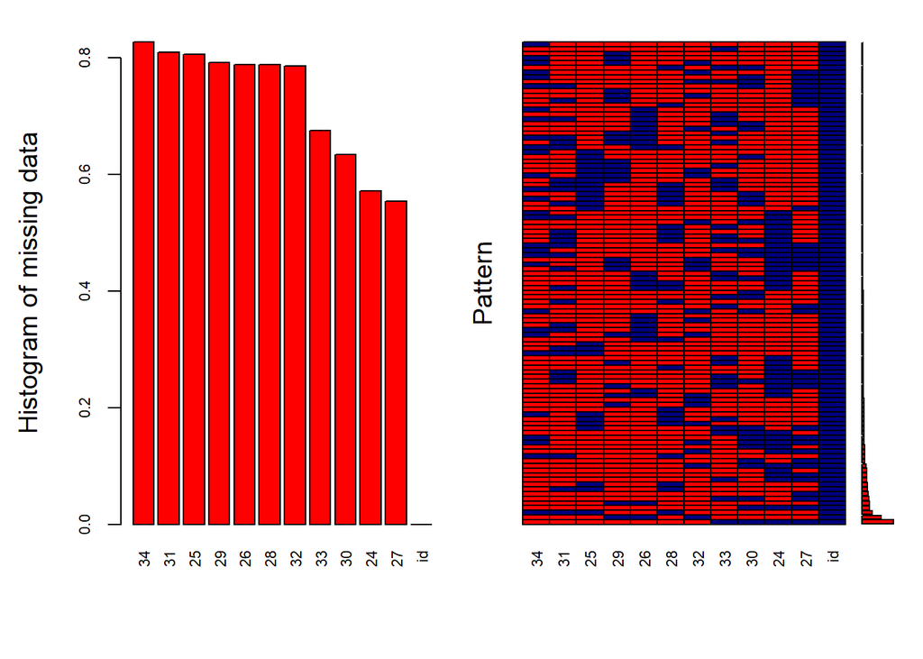

```
##
##  Variables sorted by number of missings:
##  Variable     Count
##        34 0.8273810
##        31 0.8095238
##        25 0.8065476
##        29 0.7916667
##        26 0.7886905
##        28 0.7886905
##        32 0.7857143
##        33 0.6755952
##        30 0.6339286
##        24 0.5714286
##        27 0.5535714
##        id 0.0000000
```

```r
aggr_plot <-
  aggr(
    dados1,
    col = c('navyblue', 'red'),
    numbers = TRUE,
    sortVars = TRUE,
    labels = names(dados1),
    cex.axis = .7,
    gap = 3,
    ylab = c("Histogram of missing data", "Pattern")
  )
```

```r
dados1$falt_contra <- apply(dados1[, 2:12], 1,
                            function(x)
                              sum(is.na(x)))
```

```r
table(dados1$falt_contra)
```

```
##
##   6   7   8   9  10
##  11 104 117  71  33
```

Vamos considerar apenas os casos com pelo menos 2 avaliações, ou seja, que a variável `falt_contra` seja menor ou igual a 9.

```r
dados2 <- dados1 %>%
  filter(falt_contra <= 9)
dim(dados2)
```

```
## [1] 303  13
```

Agora vamos realizar nova análise de dados faltantes.

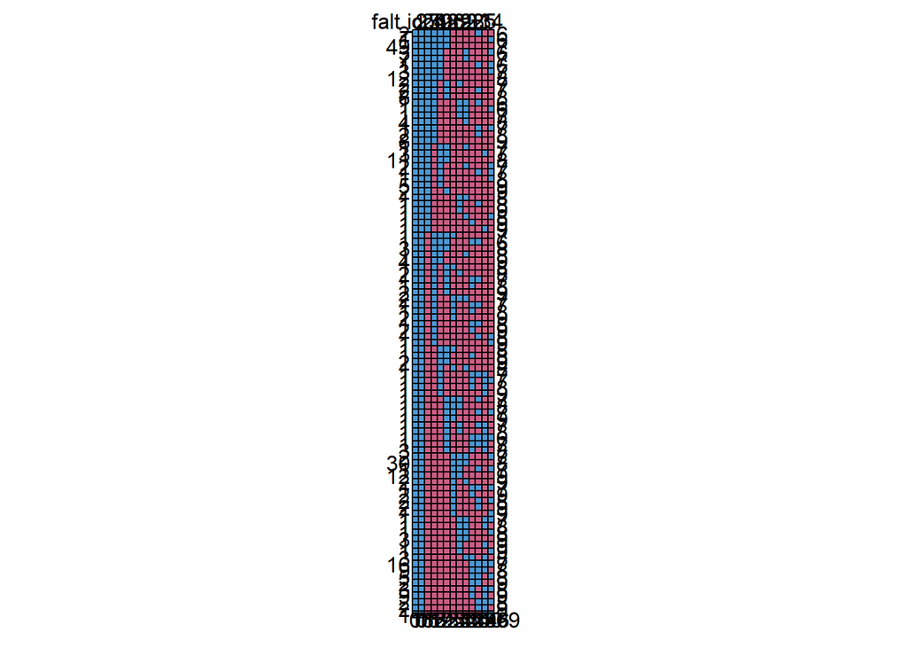

```
##    id falt_contra  27  24  30  33  26  29  32  28  31  25  34
## 2   1           1   1   1   1   1   0   0   0   0   1   0   0    6
## 1   1           1   1   1   1   1   0   0   0   0   0   0   1    6
## 49  1           1   1   1   1   1   0   0   0   0   0   0   0    7
## 3   1           1   1   1   1   0   0   0   1   0   0   0   1    6
## 7   1           1   1   1   1   0   0   0   1   0   0   0   0    7
## 1   1           1   1   1   1   0   0   0   0   0   1   0   1    6
## 3   1           1   1   1   1   0   0   0   0   0   0   0   1    7
## 12  1           1   1   1   1   0   0   0   0   0   0   0   0    8
## 2   1           1   1   1   0   1   0   1   0   0   0   0   0    7
## 2   1           1   1   1   0   1   0   0   0   0   1   0   0    7
## 8   1           1   1   1   0   1   0   0   0   0   0   0   0    8
## 1   1           1   1   1   0   0   0   1   1   0   1   0   0    6
## 1   1           1   1   1   0   0   0   1   1   0   0   0   1    6
## 1   1           1   1   1   0   0   0   1   1   0   0   0   0    7
```

[output cut: 80 more lines]

```r
md.pattern(dados2)
```

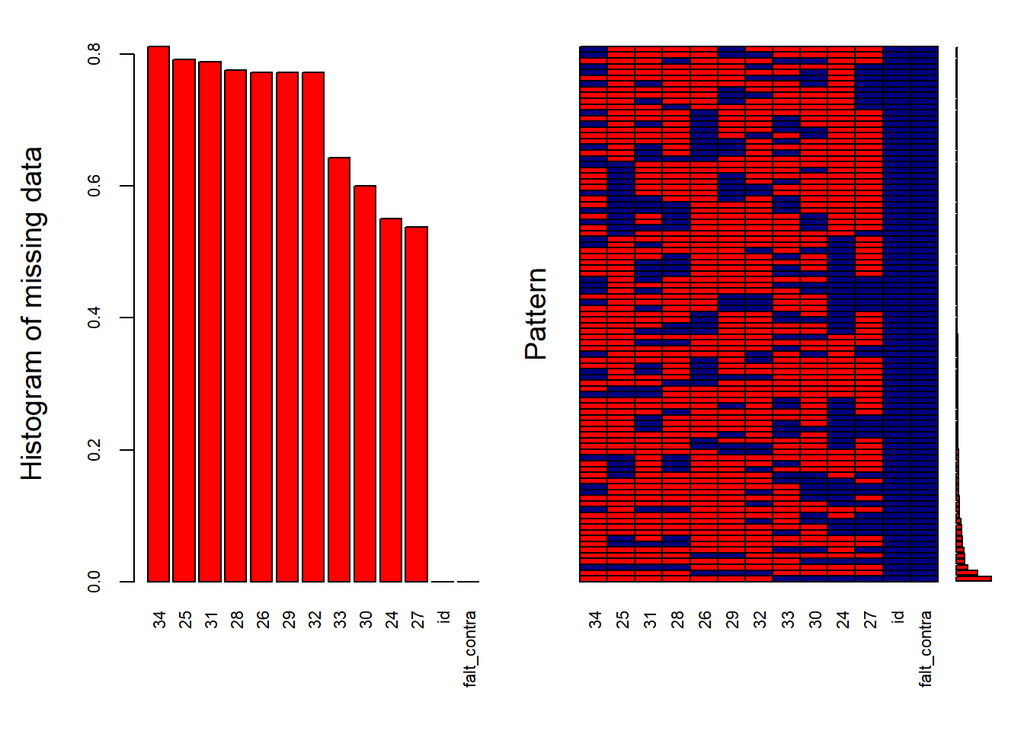

```
##
##  Variables sorted by number of missings:
##     Variable     Count
##           34 0.8118812
##           25 0.7920792
##           31 0.7887789
##           28 0.7755776
##           26 0.7722772
##           29 0.7722772
##           32 0.7722772
##           33 0.6435644
##           30 0.6006601
##           24 0.5511551
##           27 0.5379538
##           id 0.0000000
##  falt_contra 0.0000000
```

```r
aggr_plot <-
  aggr(
    dados2,
    col = c('navyblue', 'red'),
    numbers = TRUE,
    sortVars = TRUE,
    labels = names(dados2),
    cex.axis = .7,
    gap = 3,
    ylab = c("Histogram of missing data", "Pattern")
  )
```

Vamos retirar dos dados completos (com todas as variáveis) os casos não selecionados por número de contrações, ou seja, aqueles casos que não tem pelo menos duas observações.

```r
dados2_gather <- gather(data = dados2, key ="ig_aval_sem", value = "num_contra", "24", "25", "26", "27", "28", "29", "30", "31", "32", "33", "34")

dados2_gather <- dados2_gather %>%
  mutate(ig_aval_sem = as.numeric(ig_aval_sem))

ids <- unique(dados2_gather$id)

#base só com as fixas soh com dados de pelo menos 2 avaliações de número do contrações
dados_fixas_completo3 <- filter(dados_fixas_completo, id %in% ids)

dados_obs3 <- full_join(dados_fixas_completo3, dados2_gather, by= c("id"))

dados_obs3 <- dados_obs3 %>%
  arrange(id, ig_aval_sem)

str(dados_obs3)
```

```
## 'data.frame':    3333 obs. of  20 variables:
##  $ id          : num  17582 17582 17582 17582 17582 ...
##  $ ovulos      : Factor w/ 2 levels "placebo","progesterona": 1 1 1 1 1 1 1 1 1 1 ...
##  $ corion      : Factor w/ 2 levels "monocoriônica",..: 2 2 2 2 2 2 2 2 2 2 ...
##  $ im          : num  35 35 35 35 35 35 35 35 35 35 ...
##  $ tescola     : num  11 11 11 11 11 11 11 11 11 11 ...
##  $ cor_branco  : Factor w/ 2 levels "não","sim": 2 2 2 2 2 2 2 2 2 2 ...
##  $ peso_pre    : num  74 74 74 74 74 74 74 74 74 74 ...
##  $ alt         : num  1.56 1.56 1.56 1.56 1.56 1.56 1.56 1.56 1.56 1.56 ...
##  $ gesta       : num  4 4 4 4 4 4 4 4 4 4 ...
##  $ para        : num  1 1 1 1 1 1 1 1 1 1 ...
##  $ a           : num  2 2 2 2 2 2 2 2 2 2 ...
##  $ ind_ap      : Factor w/ 2 levels "não","sim": 2 2 2 2 2 2 2 2 2 2 ...
##  $ hv_tabagismo: Factor w/ 2 levels "não","sim": 1 1 1 1 1 1 1 1 1 1 ...
##  $ hv_alcool   : Factor w/ 2 levels "não","sim": 1 1 1 1 1 1 1 1 1 1 ...
##  $ hv_drogas   : Factor w/ 2 levels "não","sim": 1 1 1 1 1 1 1 1 1 1 ...
##  $ igp_parto   : num  36.7 36.7 36.7 36.7 36.7 36.7 36.7 36.7 36.7 36.7 ...
##  $ imc         : num  30.4 30.4 30.4 30.4 30.4 ...
##  $ falt_contra : int  8 8 8 8 8 8 8 8 8 8 ...
##  $ ig_aval_sem : num  24 25 26 27 28 29 30 31 32 33 ...
##  $ num_contra  : num  NA NA 3 NA NA 0 NA NA 3 NA ...
```

Vamos ver a porcentagem de dados faltantes por idade gestacional:

```r
dados_obs3 %>%
  group_by(ig_aval_sem) %>%
  summarise(ncontra = sum(is.na(num_contra))/n()
            )
```

```
## # A tibble: 11 x 2
##    ig_aval_sem ncontra
##          <dbl>   <dbl>
##  1          24   0.551
##  2          25   0.792
##  3          26   0.772
##  4          27   0.538
##  5          28   0.776
##  6          29   0.772
##  7          30   0.601
##  8          31   0.789
##  9          32   0.772
## 10          33   0.644
## 11          34   0.812
```

O próximo passo é ajusta modelo de contagem misto para número de contrações. Antes do modelo, vamos ver o histograma e boxplot.

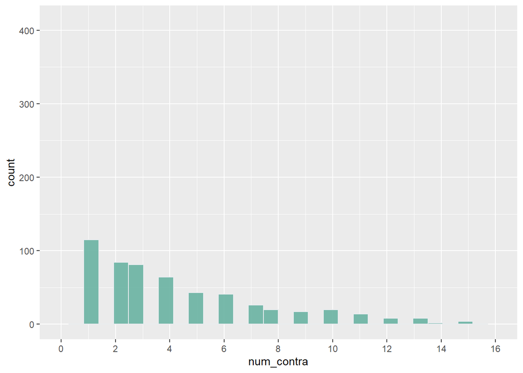

```r
ggplot(data = dados_obs3, aes(x = num_contra)) +
  geom_histogram(fill = "#69b3a2",
                 color = "#e9ecef",
                 alpha = 0.9) +
  scale_x_continuous(limits = c(0, 16), breaks = seq(0, 16, 2)) +
  theme(plot.title = element_text(size = 15))
```

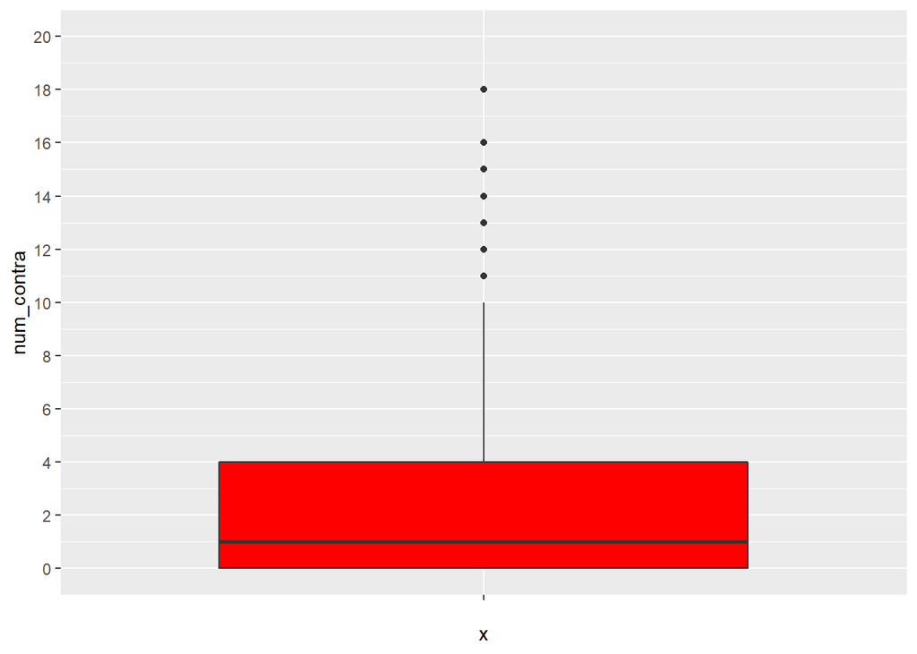

```r
ggplot(data = dados_obs3, aes(y = num_contra, x = "")) +
  geom_boxplot(fill = "red") +
  scale_y_continuous(limits = c(0, 20), breaks = seq(0, 20, 2)) +
  theme(plot.title = element_text(size = 15))
```

Vamos remover os outliers de número de contrações:

```r
dados_obs3 <- dados_obs3 %>%
  mutate(num_contra1 = ifelse(num_contra <= 10, num_contra, NA_integer_)
    )
```

```r
nbm1 <- glmmTMB(num_contra1 ~ ig_aval_sem + ovulos + corion + im + tescola + cor_branco + imc + gesta + ind_ap + hv_tabagismo + hv_alcool +  hv_drogas + (1 | id), data = dados_obs3,
                family = nbinom2)  #summary(nbm1)

nbm2 <- glmmTMB(num_contra1 ~ ig_aval_sem + ovulos + corion + im + tescola + cor_branco + imc  + (1 | id), data = dados_obs3,
                family = nbinom2)  #summary(nbm2)

nbm3 <- glmmTMB(num_contra1 ~ ig_aval_sem +  corion + im   + cor_branco + imc  + (1 | id), data = dados_obs3,
                family = nbinom2)  #summary(nbm3)

nbm4 <- glmmTMB(num_contra1 ~ ig_aval_sem +  im   + cor_branco + imc  + (1 | id), data = dados_obs3,
                family = nbinom2)   #summary(nbm4)

nbm5 <- glmmTMB(num_contra1 ~ ig_aval_sem + im + imc  + (1 | id), data = dados_obs3,
                family = nbinom2)  #summary(nbm5)

nbm8 <- glmmTMB(num_contra1 ~ ig_aval_sem + im  + imc  + (1 | id), data = dados_obs3,
                family = nbinom2) #summary(nbm8)

pred_infl <- predict(nbm8,newdata = dados_obs3,  type ="response", re.form=NA)

dados_obs3 <- dados_obs3 %>%
  mutate(pred_infl = pred_infl
    )
```

```r
gm1 <- glmer(num_contra1 ~ ig_aval_sem +  im + imc +  (1 | id), data = dados_obs3, family = "poisson")

pred_glmer <- predict(gm1, newdata = dados_obs3,  type ="response", re.form=NA)

dados_obs3 <- dados_obs3 %>%
  mutate(pred_glmer = pred_glmer
  )
```

Vamos ver o resíduo

```r
dados_obs3 <- dados_obs3 %>%
  mutate(res_infl = num_contra1 - pred_infl,
    res_glmer = num_contra1 - pred_glmer,
    res_infl_abs = abs(num_contra1 - pred_infl),
    res_glmer_abs = abs(num_contra1 - pred_glmer)
    )

summary(dados_obs3$res_glmer)
```

```
##    Min. 1st Qu.  Median    Mean 3rd Qu.    Max.    NA's
## -4.5422 -1.0752 -0.4720  0.4639  1.5859  9.3080    2409
```

```r
summary(dados_obs3$res_infl)
```

```
##    Min. 1st Qu.  Median    Mean 3rd Qu.    Max.    NA's
## -5.8385 -1.1970 -0.5232  0.2207  1.3113  9.3814    2409
```

```r
summary(dados_obs3$res_glmer_abs)
```

```
##    Min. 1st Qu.  Median    Mean 3rd Qu.    Max.    NA's
##  0.0004  0.6592  1.1948  1.7895  2.2479  9.3080    2409
```

```r
summary(dados_obs3$res_infl_abs)
```

```
##    Min. 1st Qu.  Median    Mean 3rd Qu.    Max.    NA's
##  0.0116  0.6350  1.2212  1.7997  2.3906  9.3814    2409
```

Acho que podemos ficar com nbm8. Os resíduos são similares e o glmer tem problema de convergência.

## Concatenar as medidas

```r
#vamos ver se os dados válidos de medida do colo (dados_obs2) estão em num de contra (dados_obs3)
ids_numcontra <- unique(dados_obs3$id)
sum(!(dados_obs2$id %in% ids_numcontra))
```

```
## [1] 0
```

Pelo resultado acima, observamos que todos os casos que estão na base de dados de medida do colo estão também na base de dados válidos de número de contrações.

```r
dados_obs3_aux <- dados_obs3 %>%
  select(id, ig_aval_sem, num_contra)

dados_igs_completas <- inner_join(dados_obs2, dados_obs3_aux, by = c("id", "ig_aval_sem"))
# length(unique(dados_igs_completas$id))
# str(dados_igs_completas)
```

Vamos agora imputar os dados de medida do colo e de num de contrações.

```r
pred_colo <- predict(aj, newdata = dados_igs_completas, re.form = NA)

pred_contra <-
  predict(nbm8,
          newdata = dados_igs_completas,
          type = "response",
          re.form = NA)

dados_igs_completas <- dados_igs_completas %>%
    mutate(medida_colo_imp = ifelse(
    is.na(medida_colo), pred_colo, medida_colo),
    num_contra_imp = ifelse(
    is.na(num_contra), pred_contra, num_contra)
    )
```

```r
write_xlsx(dados_igs_completas, "dados_igs_completas_11avals.xlsx")
```